# Process Subset of Samples

Ciel Baumann

2026-04-29

This RMD produces a table of ASVs for the run IDs chosen in 00_choose_sample_subset.Rmd. This script was executed on the RCH using 32 cores and multi-threading enabled because I’m impatient and it worked! I haven’t tested on a single core nor on Windows.

## Set-up environment

### Load packages

```r
#install.packages("BiocManager")
#BiocManager::install("dada2")
library(dada2, quietly=TRUE, warn.conflicts=FALSE); packageVersion("dada2")
```

```
## [1] '1.34.0'
```

### Declare globals

This RMD was created in the scripts directory of Craig’s recommended directory structure. The scripts directory contained an R project so did not need to specify absolute paths.

```r
DATA_PATH = "../data"
RESULTS_PATH = "../results"
```

### Load in data

```r
# Load in fastq data files.
# Forward and reverse fastq filenames have format:
# SAMPLEID_1.fastq.gz, SAMPLEID_2.fast.gz
fw_files <- sort(list.files(DATA_PATH, pattern="_1.fastq.gz", full.names=TRUE))
rv_files <- sort(list.files(DATA_PATH, pattern="_2.fastq.gz", full.names=TRUE))
```

```r
# Extract sample names
SAMPLE_NAMES <- sapply(strsplit(basename(fw_files), "_"), '[', 1)
```

```r
# Load in metadata
metadata <- read.csv(file=file.path(DATA_PATH, "SraRunTable.csv"))
metadata <- metadata[metadata$Run %in% SAMPLE_NAMES, ]
```

## Trim reads

### Visualise read quality profiles:

#### Visualise read quality profiles for some forward reads:

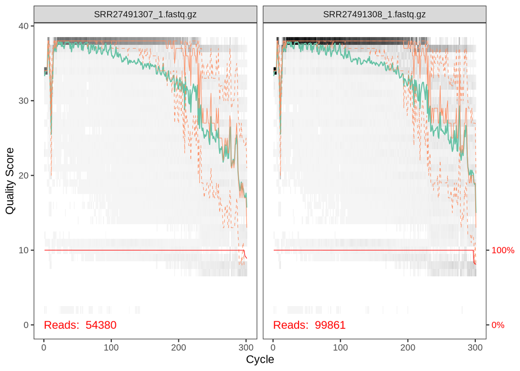

```r
plotQualityProfile(fw_files[1:2])
```

#### Visualise read quality profiles for some reverse reads:

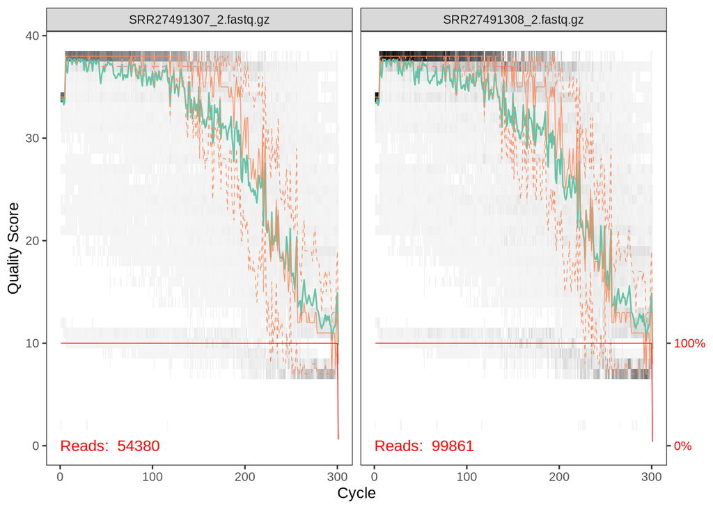

```r
plotQualityProfile(rv_files[1:2])
```

### Assign filter file names:

```r
filtFs <- file.path(RESULTS_PATH, "filtered", paste0(SAMPLE_NAMES, "_F_filt.fastq.gz"))
filtRs <- file.path(RESULTS_PATH, "filtered", paste0(SAMPLE_NAMES, "_R_filt.fastq.gz"))
names(filtFs) <- SAMPLE_NAMES
names(filtRs) <- SAMPLE_NAMES
```

### Filter and trim:

Using truncLen = c(280,200) eliminated the bottleneck during the merge step. However, looking at the above plots, this still seems to be a very wide range and allows a lot of error. But at least it merges.

```r
out <- filterAndTrim(fwd=fw_files, filt=filtFs,
                     rev=rv_files, filt.rev=filtRs,
                     truncLen = c(280,200), # c(fw_trunc, rv_trunc)
                     trimLeft = c(17,19),
                     maxN=0, # default -> DADA requires no Ns
                     maxEE=c(5,5), # Max num of 'expected errors' in a read
                     matchIDs=TRUE,
                     multithread = TRUE # Requires at least 2 cores (?)
)
```

## Prepare DADA

### Learn error rates:

```r
errF <- learnErrors(filtFs, multithread=TRUE)
```

```
## 102985540 total bases in 391580 reads from 6 samples will be used for learning the error rates.
```

```r
errR <- learnErrors(filtRs, multithread=TRUE)
```

```
## 120481745 total bases in 665645 reads from 9 samples will be used for learning the error rates.
```

### Visualise estimated error rates:

The red line is the theoretical linear error rate based on quality score, while the black line is the learned error rate based on the actual datasets.

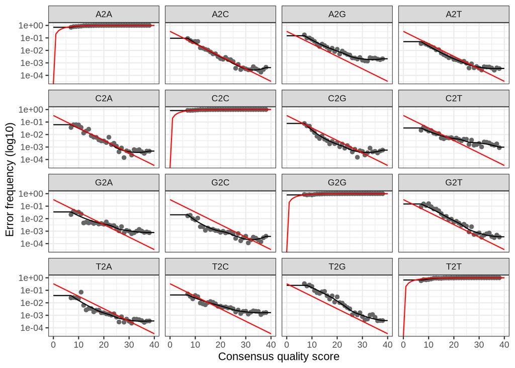

```r
# nominalQ = TRUE plots the expected error rates (red line)
plotErrors(errF, nominalQ=TRUE)
```